# LAB2

LAB 2 - Ella Haynes

```python
import numpy as np
import matplotlib
import matplotlib.pyplot as plt
import scipy
from scipy import stats
```

PROBLEM 1

QUESTION A

Average Cosmic Ray Background in 1 Day (X): 4

Number of Gamma Rays Emitted in 1 Day (Y): 6

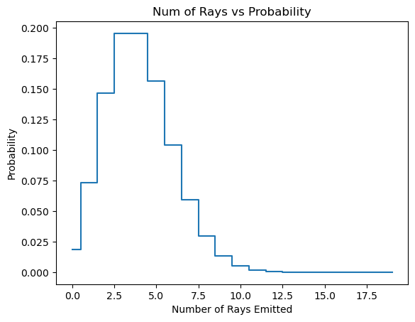

```python
x = 4

limits = np.arange(0, 20)
prob = stats.poisson.pmf(limits, x)

fig, ax = plt.subplots(1, 1)
ax.step(limits, prob, where = 'mid')
plt.title('Num of Rays vs Probability')
plt.xlabel('Number of Rays Emitted')
plt.ylabel('Probability')
plt.show()
```

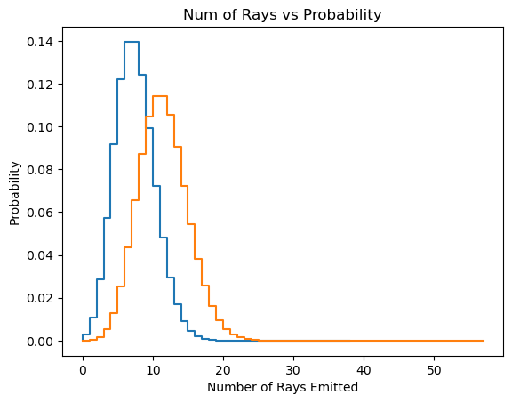

```python
day2 = np.convolve(prob, prob, mode = 'full')
day3 = np.convolve(day2, prob, mode = 'full')

fig, ax = plt.subplots(1, 1)
ax.step(np.arange(0, len(day2), 1), day2)
ax.step(np.arange(0, len(day3), 1), day3)
plt.title('Num of Rays vs Probability')
plt.xlabel('Number of Rays Emitted')
plt.ylabel('Probability')
plt.show()
```

The probability distribution becomes wider and shorter as more days are added.

QUESTION B

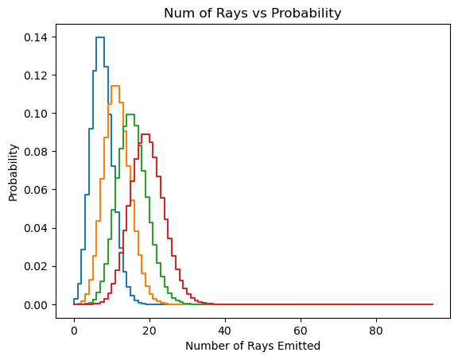

```python
day2 = np.convolve(prob, prob, mode = 'full')
day3 = np.convolve(day2, prob, mode = 'full')
day4 = np.convolve(day3, prob, mode = 'full')
day5 = np.convolve(day4, prob, mode = 'full')

fig, ax = plt.subplots(1, 1)
ax.step(np.arange(0, len(day2), 1), day2)
ax.step(np.arange(0, len(day3), 1), day3)
ax.step(np.arange(0, len(day4), 1), day4)
ax.step(np.arange(0, len(day5), 1), day5)
plt.title('Num of Rays vs Probability')
plt.xlabel('Number of Rays Emitted')
plt.ylabel('Probability')
plt.show()
```

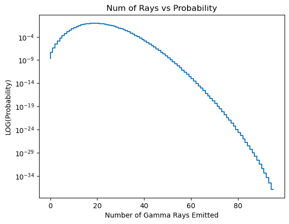

```python
fig, ax = plt.subplots(1, 1)
ax.step(np.arange(0, len(day5), 1), day5)
ax.set_yscale('log')
plt.title('Num of Rays vs Probability')
plt.xlabel('Number of Gamma Rays Emitted')
plt.ylabel('LOG(Probability)')
plt.show()
```

QUESTION C

As each day passes, the number of bins should increase appropriately (by dividing by the day number), and to keep the height from inaccurately shrinking as well, the convolution is multiplied by the day number. This is because the y axis, in this case, is probability density, not just probability.

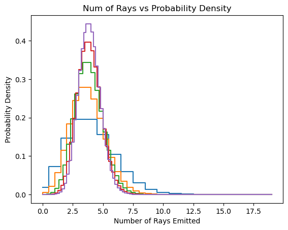

```python
fig, ax = plt.subplots(1, 1)
ax.step(limits, prob, where = 'mid')
ax.step(np.arange(0, len(day2), 1) / 2, day2 * 2)
ax.step(np.arange(0, len(day3), 1) / 3, day3 * 3)
ax.step(np.arange(0, len(day4), 1) / 4, day4 * 4)
ax.step(np.arange(0, len(day5), 1) / 5, day5 * 5)
plt.title('Num of Rays vs Probability Density')
plt.xlabel('Number of Rays Emitted')
plt.ylabel('Probability Density')
plt.show()
```

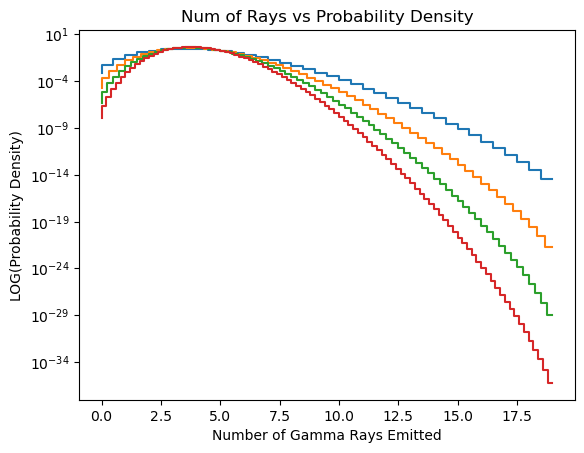

```python
fig, ax = plt.subplots(1, 1)
ax.step(np.arange(0, len(day2), 1) / 2, day2 * 2)
ax.step(np.arange(0, len(day3), 1) / 3, day3 * 3)
ax.step(np.arange(0, len(day4), 1) / 4, day4 * 4)
ax.step(np.arange(0, len(day5), 1) / 5, day5 * 5)
ax.set_yscale('log')
plt.title('Num of Rays vs Probability Density')
plt.xlabel('Number of Gamma Rays Emitted')
plt.ylabel('LOG(Probability Density)')
plt.show()
```

As the number of days increases, the distribution becomes taller and thinner. This, interestingly, is the opposite of what was observed in part B, where the distribution became shorter and wider (however, it is important to note the change in y axis labels). However, this is still backed up by the Central Limit Theorem because when averaged enough times the probability distribution becomes approximately normal. This can be tested by using a semilog-y plot, as above. As you can see, the semilog-y plot is slowly approaching an upside down parabola (though not observable within 5 days), as the days averaged are increased.

QUESTION D

N = 4

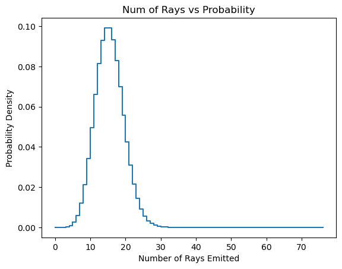

```python
fig, ax = plt.subplots(1, 1)
ax.step(np.arange(0, len(day4), 1), day4)
plt.title('Num of Rays vs Probability')
plt.xlabel('Number of Rays Emitted')
plt.ylabel('Probability Density')
plt.show()
```

```python
N = 4
y = 6

print(f'The sigma of my observation: {stats.norm.ppf(stats.poisson.sf(x, y * N)):.2f}')
```

```
The sigma of my observation: 4.85
```

PROBLEM 2

QUESTION A

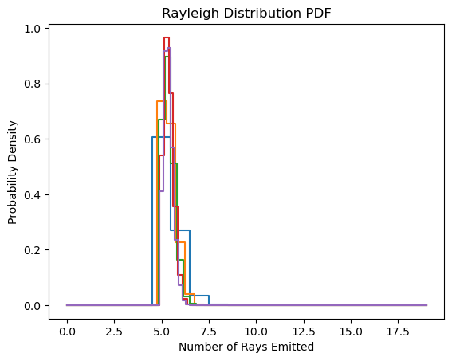

```python
x = 4

limits = np.arange(0, 20)
prob = stats.rayleigh.pdf(limits, x)

day2 = np.convolve(prob, prob, mode = 'full')
day3 = np.convolve(day2, prob, mode = 'full')
day4 = np.convolve(day3, prob, mode = 'full')
day5 = np.convolve(day4, prob, mode = 'full')

fig, ax = plt.subplots(1, 1)
ax.step(limits, prob, where = 'mid')
ax.step(np.arange(0, len(day2), 1) / 2, day2 * 2, where = 'mid')
ax.step(np.arange(0, len(day3), 1) / 3, day3 * 3, where = 'mid')
ax.step(np.arange(0, len(day4), 1) / 4, day4 * 4, where = 'mid')
ax.step(np.arange(0, len(day5), 1) / 5, day5 * 5, where = 'mid')
plt.title('Rayleigh Distribution PDF')
plt.xlabel('Number of Rays Emitted')
plt.ylabel('Probability Density')
plt.show()
```

The distribution becomes taller and thinner as the number of observing intervals averaged increases.

QUESTION B

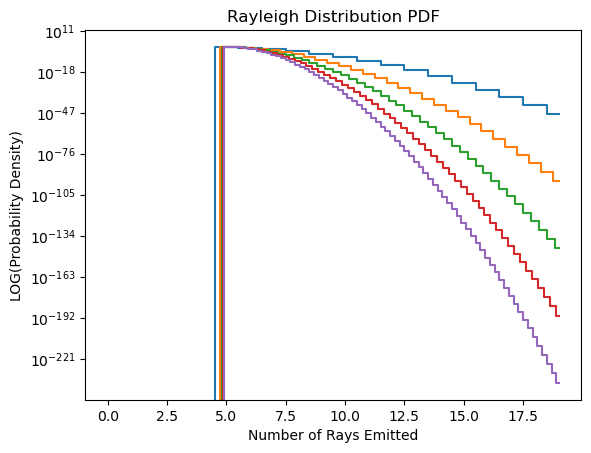

```python
fig, ax = plt.subplots(1, 1)
ax.step(limits, prob, where = 'mid')
ax.step(np.arange(0, len(day2), 1) / 2, day2 * 2, where = 'mid')
ax.step(np.arange(0, len(day3), 1) / 3, day3 * 3, where = 'mid')
ax.step(np.arange(0, len(day4), 1) / 4, day4 * 4, where = 'mid')
ax.step(np.arange(0, len(day5), 1) / 5, day5 * 5, where = 'mid')
plt.title('Rayleigh Distribution PDF')
plt.xlabel('Number of Rays Emitted')
plt.ylabel('LOG(Probability Density)')
ax.set_yscale('log')
plt.show()
```

The distribution becomes less wide and taller as you average over more observing intervals, for example, five, as above. To evaluate if it approaches a Gaussian distribution you use a semilog-y plot. The first 5 days did not appear as an upside-down parabola, so I expand the intervals to 320:

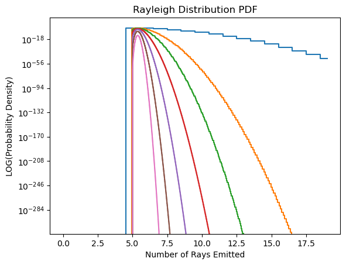

```python
fig, ax = plt.subplots(1, 1)

day6 = np.convolve(day5, prob, mode = 'full')
day7 = np.convolve(day6, prob, mode = 'full')
day8 = np.convolve(day7, prob, mode = 'full')
day9 = np.convolve(day8, prob, mode = 'full')
day10 = np.convolve(day9, prob, mode = 'full')
day20 = np.convolve(day10, day10, mode = 'full')
day40 = np.convolve(day20, day20, mode = 'full')
day80 = np.convolve(day40, day40, mode = 'full')
day160 = np.convolve(day80, day80, mode = 'full')
day320 = np.convolve(day160, day160, mode = 'full')

ax.step(limits, prob, where = 'mid')
ax.step(np.arange(0, len(day10), 1) / 10, day10 * 10, where = 'mid')
ax.step(np.arange(0, len(day20), 1) / 20, day20 * 20, where = 'mid')
ax.step(np.arange(0, len(day40), 1) / 40, day40 * 40, where = 'mid')
ax.step(np.arange(0, len(day80), 1) / 80, day80 * 80, where = 'mid')
ax.step(np.arange(0, len(day160), 1) / 160, day160 * 160, where = 'mid')
ax.step(np.arange(0, len(day320), 1) / 320, day320 * 320, where = 'mid')
plt.title('Rayleigh Distribution PDF')
plt.xlabel('Number of Rays Emitted')
plt.ylabel('LOG(Probability Density)')
ax.set_yscale('log')
plt.show()
```

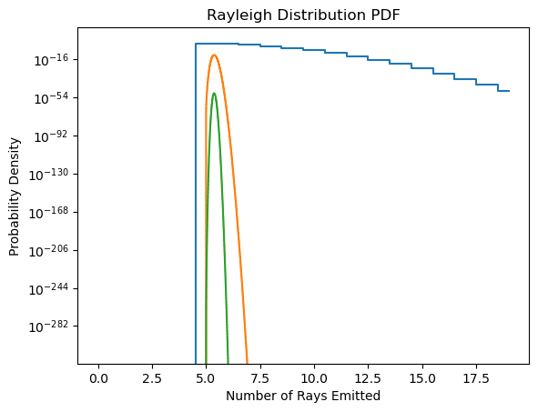

```python
day640 = np.convolve(day320, day320, mode = 'full')
day1280 = np.convolve(day640, day640, mode = 'full')

fig, ax = plt.subplots(1, 1)
ax.step(limits, prob, where = 'mid')
ax.step(np.arange(0, len(day320), 1) / 320, day320 * 320, where = 'mid')
ax.step(np.arange(0, len(day1280), 1) / 1280, day1280 * 1280, where = 'mid')
plt.title('Rayleigh Distribution PDF')
plt.xlabel('Number of Rays Emitted')
plt.ylabel('Probability Density')
ax.set_yscale('log')
plt.show()
```

PROBLEM 3

VERSION 1

QUESTION A

Width (X) = 6

Signal Strength (Y) = 10.9

```python
x = 6 # -> stdeva = 3
y = 10.9

print(f'The sigma of my observation: {stats.norm.isf(stats.norm.sf(y, loc = 0, scale = 3)):.2f}')
```

```
The sigma of my observation: 3.63
```

Because the sigma is less than 5, I cannot claim a discovery.

VERSION 2

QUESTION B

Statistical Question: How does the value of the background pixels change when attempting to locate a signal in 10,000 pixels?

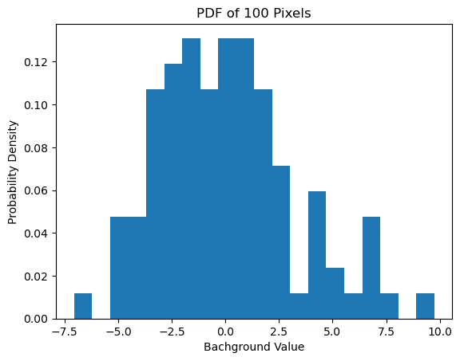

```python
g0 = stats.norm.rvs(loc = 0, scale = 3, size = 100)

fig, ax = plt.subplots(1, 1)
ax.hist(g0, 20, density = True)
plt.title('PDF of 100 Pixels')
plt.xlabel('Bachground Value')
plt.ylabel('Probability Density')
plt.show()
```

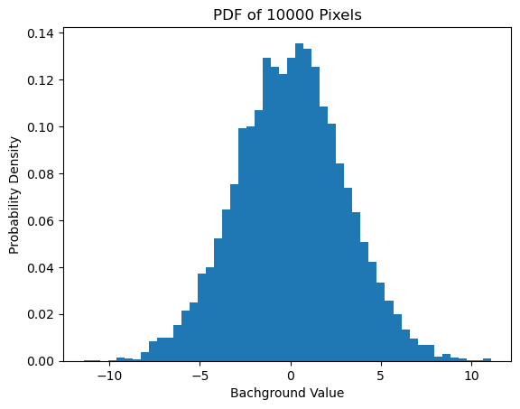

```python
g0 = stats.norm.rvs(loc = 0, scale = 3, size = 10)
g = stats.norm.rvs(loc = 0, scale = 3, size = 10000)

fig, ax = plt.subplots(1, 1)
ax.hist(g, 50, density = True)
plt.title('PDF of 10000 Pixels')
plt.xlabel('Bachground Value')
plt.ylabel('Probability Density')
plt.show()
```

As you can see, as the number of samples increases, the distribution becomes more normal.

QUESTION C

10.9 appears to have approximately 2 bins to the right of it, so I sum the probabilities to calculate the total probability greater than my selected number.

```python
p = ax.patches

prob = p[48].get_height() + p[49].get_height()

print(f'The sigma of my observation: {stats.norm.isf(prob * 1/3):.2f}')
```

```
The sigma of my observation: 3.37
```